# Predicting Hockey Playoff Performance

Margaret Hoskins

With the 2025 playoff season upon us, the question on every hockey fan’s mind is the same—who will be the Stanley Cup Champion?

My goal was to create a model that can predict the final four teams in the playoffs based off of regular season statistics, and in doing so identify which regular seasons statistics are the biggest predictors of success in the playoffs.

THe packages used for this project were `tidyverse`, `pROC`, `rpart`, `rpart.plot`, `randomForest`, and `janitor`.

# Data Wrangling

The data I used is from [Hockey Reference](https://www.hockey-reference.com). I downloaded CSV files of the last ten years of regular season data and hockey data, read them in using `read.csv`, and saved each of them as its own dataframe.

```r
season_data_2015 <-
  read.csv("nhl_season_data_2015.csv")

season_data_2016 <-
  read.csv("nhl_season_data_2016.csv")

season_data_2017 <-
  read.csv("nhl_season_data_2017.csv")

season_data_2018 <-
  read.csv("nhl_season_data_2018.csv")

season_data_2019 <-
  read.csv("nhl_season_data_2019.csv")

season_data_2020 <-
  read.csv("nhl_season_data_2020.csv")

season_data_2021 <-
  read.csv("nhl_season_data_2021.csv")

season_data_2022 <-
  read.csv("nhl_season_data_2022.csv")

season_data_2023 <-
  read.csv("nhl_season_data_2023.csv")

season_data_2024 <-
  read.csv("nhl_season_data_2024.csv")
```

```r
playoff_data_2015 <-
  read.csv("nhl_playoff_data_2015.csv")

playoff_data_2016 <-
  read.csv("nhl_playoff_data_2016.csv")

playoff_data_2017 <-
  read.csv("nhl_playoff_data_2017.csv")

playoff_data_2018 <-
  read.csv("nhl_playoff_data_2018.csv")

playoff_data_2019 <-
  read.csv("nhl_playoff_data_2019.csv")

playoff_data_2020 <-
  read.csv("nhl_playoff_data_2020.csv")

playoff_data_2021 <-
  read.csv("nhl_playoff_data_2021.csv")

playoff_data_2022 <-
  read.csv("nhl_playoff_data_2022.csv")

playoff_data_2023 <-
  read.csv("nhl_playoff_data_2023.csv")

playoff_data_2024 <-
  read.csv("nhl_playoff_data_2024.csv")
```

Before compiling the data, I needed to be able to identify which year each data point came from, so I added a `YEAR` column to each dataframe before using `bind_rows` to create a `season_data_all` dataframe and a `playoff_data_all` dataframe.

```r
season_data_2015 <-
season_data_2015 |>
  mutate(YEAR = "2015", .before = GP)

season_data_2016 <-
season_data_2016 |>
  mutate(YEAR = "2016", .before = GP)

season_data_2017 <-
season_data_2017 |>
  mutate(YEAR = "2017", .before = GP)

season_data_2018 <-
season_data_2018 |>
  mutate(YEAR = "2018", .before = GP)

season_data_2019 <-
season_data_2019 |>
  mutate(YEAR = "2019", .before = GP)

season_data_2020 <-
season_data_2020 |>
  mutate(YEAR = "2020", .before = GP)

season_data_2021 <-
season_data_2021 |>
  mutate(YEAR = "2021", .before = GP)

season_data_2022 <-
season_data_2022 |>
  mutate(YEAR = "2022", .before = GP)

season_data_2023 <-
season_data_2023 |>
  mutate(YEAR = "2023", .before = GP)

season_data_2024 <-
season_data_2024 |>
  mutate(YEAR = "2024", .before = GP)

season_data_all <-
bind_rows(season_data_2015,
          season_data_2016,
          season_data_2017,
          season_data_2018,
          season_data_2019,
          season_data_2020,
          season_data_2021,
          season_data_2022,
          season_data_2023,
          season_data_2024)
```

```r
playoff_data_2015 <-
playoff_data_2015 |>
  mutate(YEAR = "2015", .before = GP)

playoff_data_2016 <-
playoff_data_2016 |>
  mutate(YEAR = "2016", .before = GP)

playoff_data_2017 <-
playoff_data_2017 |>
  mutate(YEAR = "2017", .before = GP)

playoff_data_2018 <-
playoff_data_2018 |>
  mutate(YEAR = "2018", .before = GP)

playoff_data_2019 <-
playoff_data_2019 |>
  mutate(YEAR = "2019", .before = GP)

playoff_data_2020 <-
playoff_data_2020 |>
  mutate(YEAR = "2020", .before = GP)

playoff_data_2021 <-
playoff_data_2021 |>
  mutate(YEAR = "2021", .before = GP)

playoff_data_2022 <-
playoff_data_2022 |>
  mutate(YEAR = "2022", .before = GP)

playoff_data_2023 <-
playoff_data_2023 |>
  mutate(YEAR = "2023", .before = GP)

playoff_data_2024 <-
playoff_data_2024 |>
  mutate(YEAR = "2024", .before = GP)

playoff_data_all <-
bind_rows(playoff_data_2015,
          playoff_data_2016,
          playoff_data_2017,
          playoff_data_2018,
          playoff_data_2019,
          playoff_data_2020,
          playoff_data_2021,
          playoff_data_2022,
          playoff_data_2023,
          playoff_data_2024)
```

I used `clean_names` to standardize variable names to snake case.

```r
season_data_all <-
season_data_all |>
  clean_names()

playoff_data_all <-
playoff_data_all |>
  clean_names()
```

```r
head(season_data_all)
```

|  | rk | team | av_age | year | gp | w | l | ol | pts | pts_2 | gf | ga | sow | sol | srs | sos | gf_g | ga_g | pp | ppo | pp_2 | ppa | ppoa | pk | sh | sha | pim_g | o_pim_g | s | … |
| --- | --- | --- | --- | --- | --- | --- | --- | --- | --- | --- | --- | --- | --- | --- | --- | --- | --- | --- | --- | --- | --- | --- | --- | --- | --- | --- | --- | --- | --- | --- |
| 1 | 1 | New York Rangers* | 29.4 | 2015 | 82 | 53 | 22 | 7 | 113 | 0.689 | 248 | 187 | 4 | 5 | 0.69 | -0.04 | 3.02 | 2.28 | 39 | 232 | 16.81 | 37 | 235 | 84.26 | 9 | 6 | 8.7 | 8.2 | 2582 | … |
| 2 | 2 | Montreal Canadiens* | 28.4 | 2015 | 82 | 50 | 22 | 10 | 110 | 0.671 | 214 | 184 | 7 | 5 | 0.36 | -0.03 | 2.61 | 2.24 | 40 | 242 | 16.53 | 42 | 257 | 83.66 | 7 | 4 | 10.2 | 9.3 | 2334 | … |
| 3 | 3 | Anaheim Ducks* | 27.0 | 2015 | 82 | 51 | 24 | 7 | 109 | 0.665 | 228 | 221 | 8 | 5 | 0.10 | -0.03 | 2.78 | 2.70 | 37 | 236 | 15.68 | 52 | 274 | 81.02 | 9 | 6 | 10.8 | 9.8 | 2458 | … |
| 4 | 4 | St. Louis Blues* | 28.3 | 2015 | 82 | 51 | 24 | 7 | 109 | 0.665 | 239 | 197 | 9 | 4 | 0.59 | 0.02 | 2.91 | 2.40 | 56 | 251 | 22.31 | 42 | 257 | 83.66 | 2 | 5 | 11.0 | 10.6 | 2535 | … |
| 5 | 5 | Tampa Bay Lightning* | 26.9 | 2015 | 82 | 50 | 24 | 8 | 108 | 0.659 | 259 | 206 | 3 | 5 | 0.57 | -0.06 | 3.16 | 2.51 | 53 | 282 | 18.79 | 42 | 257 | 83.66 | 7 | 6 | 9.9 | 10.5 | 2428 | … |
| 6 | 6 | Nashville Predators* | 28.4 | 2015 | 82 | 47 | 25 | 10 | 104 | 0.634 | 226 | 202 | 6 | 6 | 0.33 | 0.03 | 2.76 | 2.46 | 42 | 259 | 16.22 | 45 | 234 | 80.77 | 4 | 5 | 8.5 | 9.3 | 2614 | … |

```r
head(playoff_data_all)
```

|  | rk | team | year | gp | w | l | t | ow | ol | w_l | g | ga | diff |
| --- | --- | --- | --- | --- | --- | --- | --- | --- | --- | --- | --- | --- | --- |
| 1 | 1 | Chicago Blackhawks | 2015 | 23 | 16 | 7 | 0 | 4 | 1 | 0.696 | 69 | 60 | 9 |
| 2 | 2 | Tampa Bay Lightning | 2015 | 26 | 14 | 12 | 0 | 3 | 0 | 0.538 | 65 | 62 | 3 |
| 3 | 3 | Anaheim Ducks | 2015 | 16 | 11 | 5 | 0 | 3 | 3 | 0.688 | 57 | 42 | 15 |
| 4 | 4 | New York Rangers | 2015 | 19 | 11 | 8 | 0 | 4 | 1 | 0.579 | 45 | 41 | 4 |
| 5 | 5 | Washington Capitals | 2015 | 14 | 7 | 7 | 0 | 1 | 3 | 0.500 | 28 | 28 | 0 |
| 6 | 6 | Montreal Canadiens | 2015 | 12 | 6 | 6 | 0 | 2 | 1 | 0.500 | 25 | 29 | -4 |

Now I had two distinct dataframes with cleaned names, but a new issue presented itself—in the regular season data, teams that made it to that year’s playoffs are marked with an asterisk. This would pose a problem when trying to join the dataframes, so I used `str_extract` and a regular expression to keep all characters except `*`.

```r
season_data_all <-
season_data_all |>
  mutate(team = str_extract(team, pattern = "[^\\*]*"))
```

To prevent confusion with all of the other dataframes using the same naming pattern, I saved them under the new names `data_season` and `data_playoff`.

```r
data_season <-
  season_data_all

data_playoff <-
  playoff_data_all
```

I narrowed my dataframes to the variables I needed to work with—more about that below.

```r
data_season <-
data_season |>
  select(team, year, gf, ga, gf_g, ga_g, pp_2, pk, s_2)

data_playoff <-
data_playoff |>
  select(rk, team, year)
```

I used a `left_join` to create a new dataframe `joined_data`.

```r
joined_data <-
left_join(data_playoff, data_season,
          join_by(team == team, year == year))
```

Below, I renamed the variables for clarity.

```r
joined_data <-
joined_data |>
  rename(rank_playoff = rk,
         goals_for = gf,
         goals_against = ga,
         goals_for_per_game = gf_g,
         goals_against_per_game = ga_g,
         pp_percent = pp_2,
         pk_percent = pk,
         shooting_percent = s_2
         )
```

I needed a variable to identfy which teams were in the final four during their playoff season, so I split the data into `top4` and `not_top4`, created a new `top_4`column with corresponding values, then rejoined them using `bind_rows`

```r
top4 <-
  joined_data |>
  filter(rank_playoff <= 4)

not_top4 <-
  joined_data |>
  filter(rank_playoff > 4)

top4 <-
  top4 |>
  mutate(top_4 = "Top 4")

not_top4 <-
  not_top4 |>
  mutate(top_4 = "Not Top 4")

joined_data <-
bind_rows(top4, not_top4)
```

Finally, I mutated `top_4` to be a factor for modeling purposes, and created a new variable `difference`, discussed in the next section.

```r
joined_data <-
  joined_data |>
  mutate(top_4 = fct(top_4, levels = c("Not Top 4", "Top 4")))

joined_data <-
joined_data |>
  mutate(difference = goals_for - goals_against) |>
  drop_na()
```

# The Variables

`rank_playoff` The team’s final rank in the playoffs.

`team` The team name.

`year` The year the data is from.

`goals_for` The total number of goals scored by the team for that season.

`goals_against` The total number of goals scored against the team for that season.

`goals_for_per_game` The average number of goals scored for a team per game.

`goals_against_per_game` The average number of goals scored against a team per game.

`pp_percent` The percentage of powerplays (when the team has a 1-player advantage) scored during.

`pk_percent` The percent of penalty kills; a.k.a. the percentage of penalties scored during.

`shooting_percent` The percentage of shots scored on.

`top_4` A qualitative variable marking if a team was in the final four of that season’s playoffs.

`difference` The goal differential; a.k.a. the total number of goals scored vs. the total number of goals scored against during the regular season.

# Modeling

To begin modeing, I split my data into trainng data and testing data.

```r
set.seed(373)
train_indexes <-
as.vector(createDataPartition(joined_data$top_4, p =
0.75, list = FALSE))

data_train <- slice(joined_data, train_indexes)

data_test <- slice(joined_data, -train_indexes)
```

I decided to start with a random forest, using all of the regular season variables.

```r
rf_model <- randomForest(top_4~goals_for_per_game + goals_against_per_game + pp_percent + pk_percent +
shooting_percent + difference,
    data = data_train)
```

The random forest model had an error rate of 24.6%, which wasn’t bad, but I was concerned about the model’s inability to identify teams as being in the top 4 specifically—Top 4 had a class error of 83.3%.

I checked the importance of all the variables in the random forest and it indicated that `pp_percent` and `pk_percent` were the most important variables, so I tried another random forest using just those variables.

```r
rf_model
```

```
##
## Call:
##  randomForest(formula = top_4 ~ goals_for_per_game + goals_against_per_game +      pp_percent + pk_percent + shooting_percent + difference,      data = data_train)
##                Type of random forest: classification
##                      Number of trees: 500
## No. of variables tried at each split: 2
##
##         OOB estimate of  error rate: 24.6%
## Confusion matrix:
##           Not Top 4 Top 4 class.error
## Not Top 4        90     6   0.0625000
## Top 4            25     5   0.8333333
```

```r
importance(rf_model)
```

```
##                        MeanDecreaseGini
## goals_for_per_game             7.519039
## goals_against_per_game         7.720415
## pp_percent                     8.217285
## pk_percent                     8.100322
## shooting_percent               6.593413
## difference                     7.200558
```

```r
rf_model_2 <- randomForest(top_4~pp_percent + pk_percent,
    data = data_train)
```

```r
rf_model_2
```

```
##
## Call:
##  randomForest(formula = top_4 ~ pp_percent + pk_percent, data = data_train)
##                Type of random forest: classification
##                      Number of trees: 500
## No. of variables tried at each split: 1
##
##         OOB estimate of  error rate: 26.98%
## Confusion matrix:
##           Not Top 4 Top 4 class.error
## Not Top 4        85    11   0.1145833
## Top 4            23     7   0.7666667
```

```r
importance(rf_model_2)
```

```
##            MeanDecreaseGini
## pp_percent         22.10801
## pk_percent         22.90235
```

This new random forest model had a slightly higher out-of-bag-error rate, but a lower class error for Top 4.

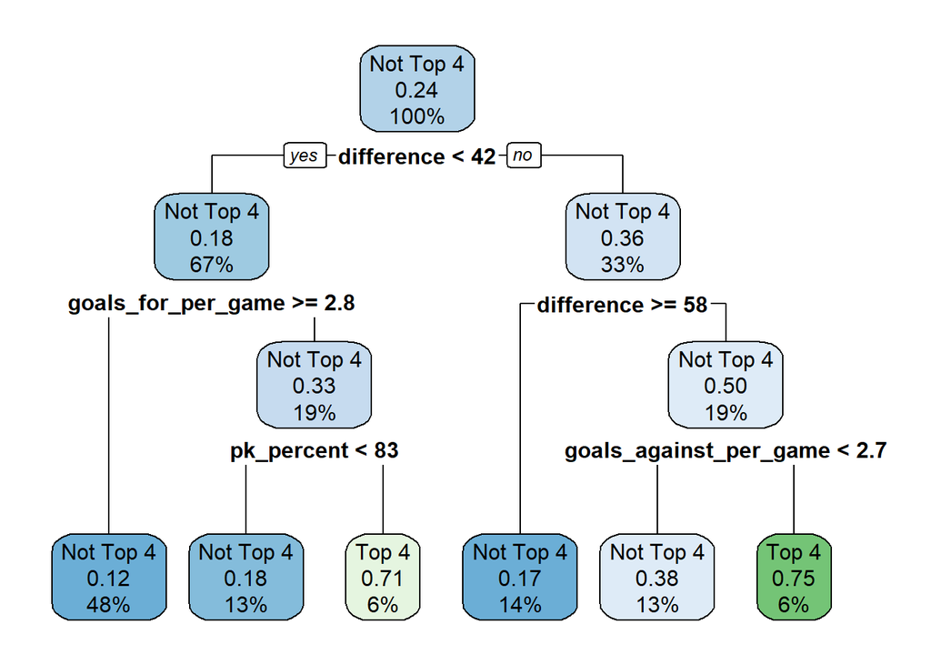

```r
decision_tree <-
  rpart(top_4~goals_for_per_game +
          goals_against_per_game +
          pp_percent + pk_percent +
          difference,
        data = data_train,
        method = "class")

rpart.plot(decision_tree)
```

To compare my three models and see which is best, I plotted the ROC curves for each model against each other.

```r
predicted_probs_forest <- predict(rf_model,
newdata = data_test, type = "prob")

roc_obj_forest <- roc(data_test$top_4,
predicted_probs_forest[, "Top 4"])
predicted_probs_forest_2 <- predict(rf_model_2,
newdata = data_test, type = "prob")

roc_obj_forest_2 <- roc(data_test$top_4,
predicted_probs_forest_2[, "Top 4"])
predicted_probs_tree <- predict(decision_tree,
newdata = data_test, type = "prob")

roc_obj_tree <- roc(data_test$top_4,
predicted_probs_tree[, "Top 4"])
```

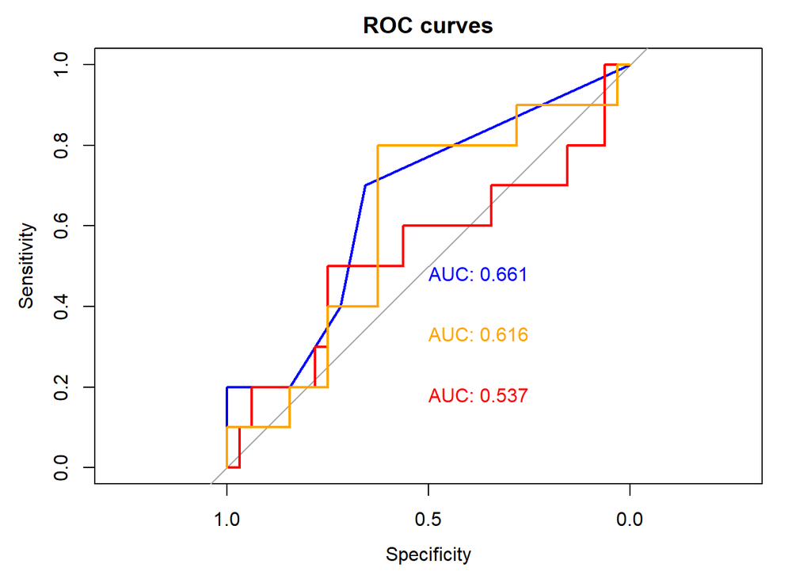

```r
plot(roc_obj_tree, main = "ROC curves",
print.auc = TRUE, col = "blue")

plot(roc_obj_forest, add = TRUE,
print.auc = TRUE,col = "red", print.auc.y = 0.2)

plot(roc_obj_forest_2, add = TRUE,
print.auc = TRUE,col = "orange", print.auc.y = 0.35)
```

In the above plot, The blue ROC curve is the decision tree, the orange ROC curve is the second random forest, and the red ROC curve is the first random forest.

# Conclusions and Next Steps

Of the three models, the decision tree was the best at identifying which teams would be in the final four. I think this is due to the sparseness of the data—over ten years, there are only 40 top 4 teams. The model’s still not perfect, as it’s only about ten percent better than random guessing.

While I think this model is a good start, it’s most definitely a work in progress. In order to increase the accuracy of the model I think I’ll need to use more years of data, and perhaps widen the scope of what I’m predicting (for example, the top 8 teams rather than the top 4).